# Campus Mobility & Commuter Habits Study

Irina Benedyk

2026-02-13

# Campus Mobility & Commuter Habits Study

This report presents an analysis of the Campus Mobility & Commuter Habits Study, a survey designed to understand how the university community navigates travel to and from UB North campus. With a sample size of $n = 104$ respondents, the study examines the primary modes of transportation, the prevalence of car dependency, and the specific barriers preventing the adoption of more sustainable alternatives like transit, cycling, and walking.

Key focus areas include the impact of Buffalo’s winter weather on commuting choices, the adequacy of current parking infrastructure, and the specific improvements, such as shuttle reliability and safety features, that could incentivize a shift away from single-occupancy vehicle travel.

Data collected during *Spring 2026* semester among students of *CIE439* for course project.

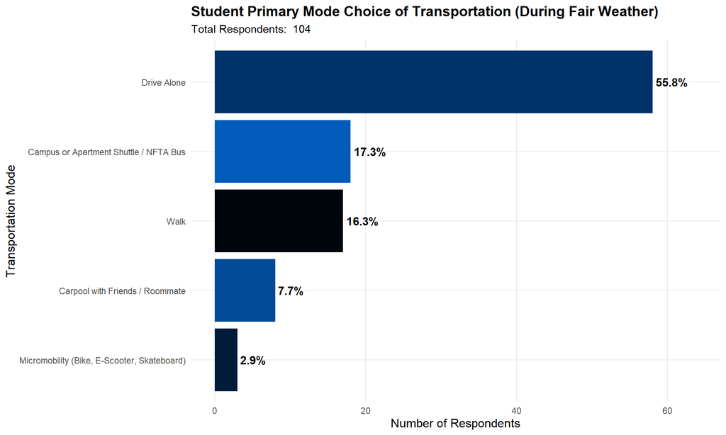

## Distribution of Student Residence

The following chart illustrates the geographical distribution of the survey participants relative to the UB North Campus. By categorizing where students live we can better understand the baseline travel requirements for our population.

As shown, the largest segment of the respondent pool consists of long-distance commuters, which significantly influences the high demand for parking and vehicle infrastructure.

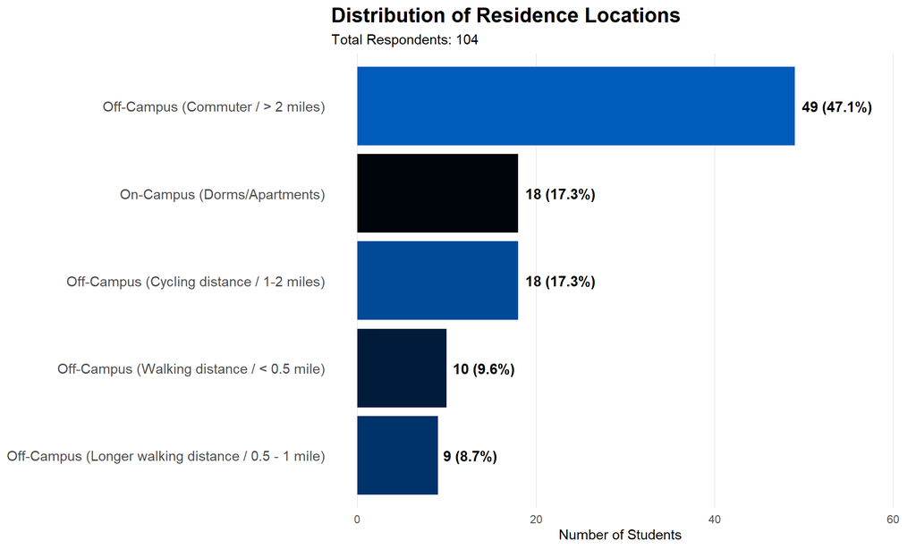

## Student Arrival Times

The following visualization identifies the primary windows of campus arrival, revealing the peak periods of traffic and transit demand that occur throughout the morning hours.

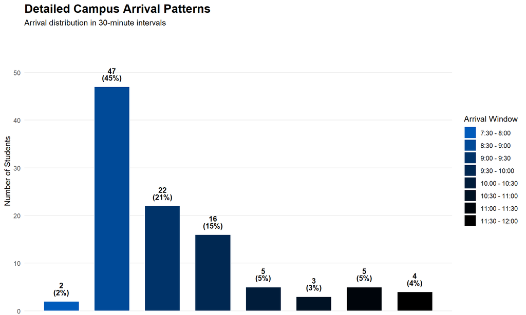

## What are Mode Choices of Individuals from Different Residential Locations

The visualization below utilizes a 100% stacked bar chart to illustrate the proportion of travel mode choices within each residential category, allowing for a direct comparison of habits regardless of group size.

A critical observation is how many of students use driving as a primary mode while living on campus or within half of the mile from the campus.

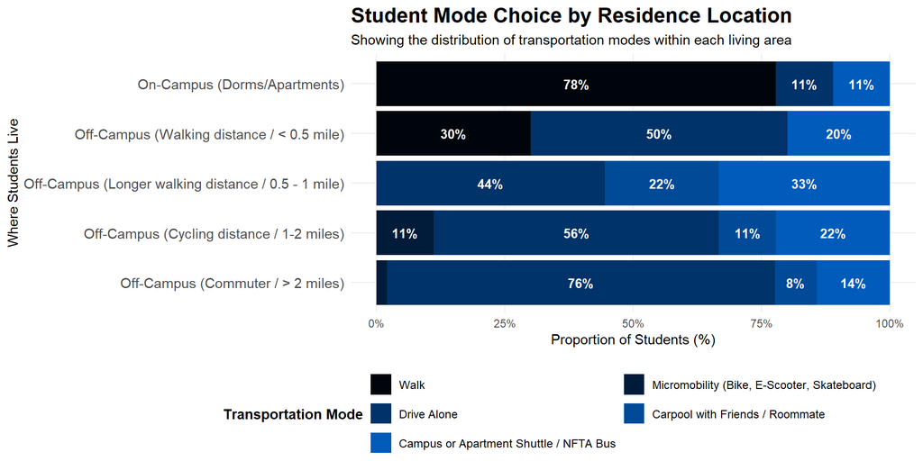

## Public Transit Concerns

The following visualizations examine five key areas of student public transit concerns: frequency, reliability, crowding, travel time, and stop locations. By comparing the responses of men and women, we can identify whether certain service gaps are perceived more acutely by different segments of the student body.

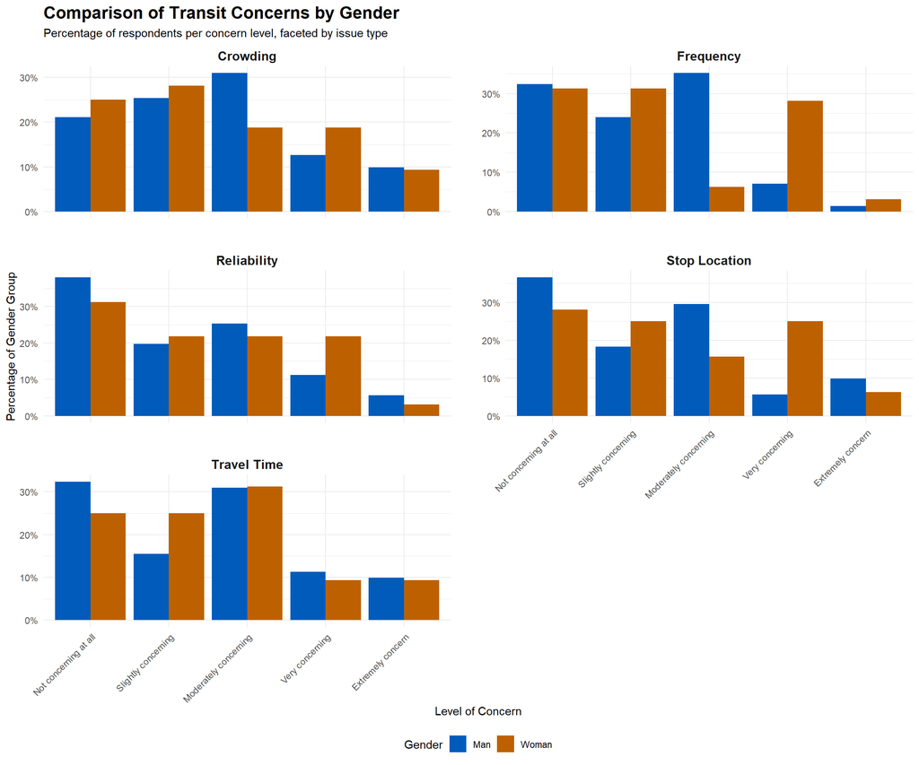

## Campus Parking Adequacy

Campus parking is often cited as a significant stressor for the university community, directly impacting arrival times and overall accessibility. The following chart breaks down the perceived adequacy of campus parking for private vehicles, rated on a scale of 1 (Poor) to 5 (Excellent). By comparing these ratings between men and women, we can determine if there is a shared consensus regarding the insufficiency of current facilities or if specific demographic groups feel the impact of parking shortages more severely.

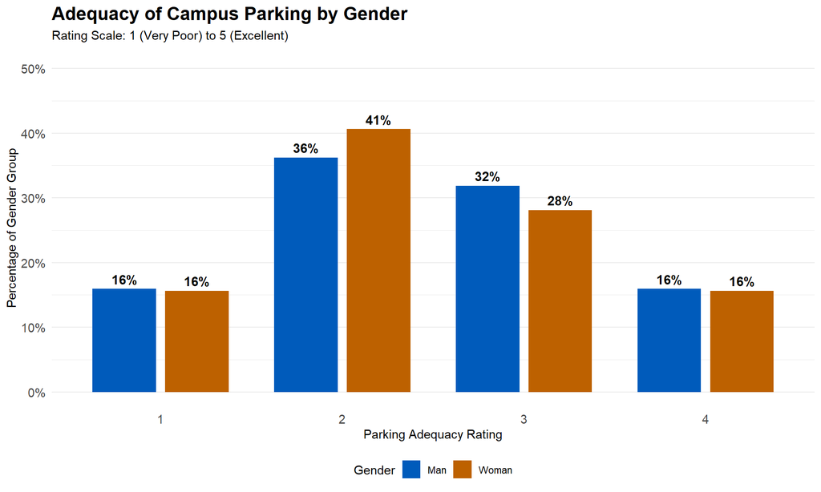

## Evaluating Campus Bike Infrastructure

For micromobility to be a viable alternative to driving, the supporting infrastructure—such as secure storage, safe travel lanes, and maintenance support—must meet the needs and safety expectations of all users. The following visualizations examine how men and women rate three critical components of the campus biking environment: the availability of bike racks, the safety of dedicated bike lanes, and the accessibility of repair stations.

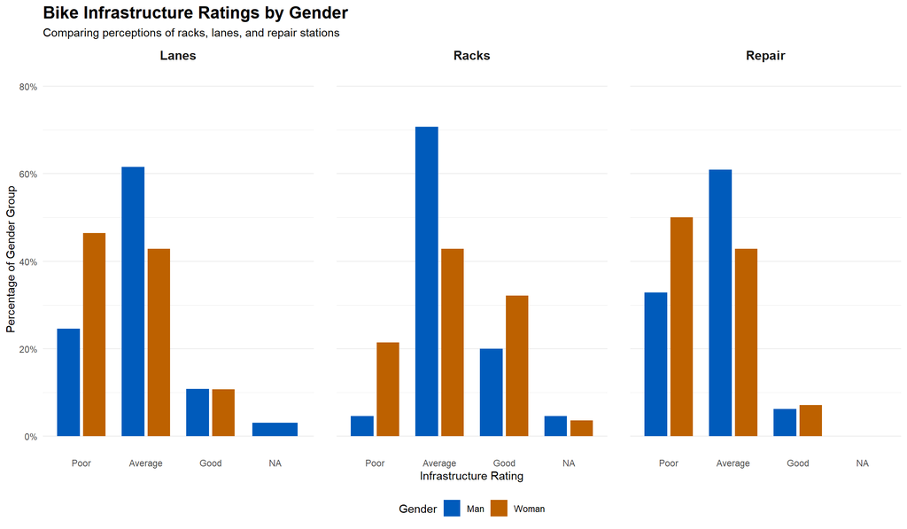

## Understanding Why Students Choose Not to Bike or Scooter to Campus

Even when infrastructure is available, several personal and environmental factors can prevent students from adopting micromobility (bicycles, e-scooters, or skateboards) as their primary mode of transport. The following chart identifies the most significant deterrents reported by students, ranging from Buffalo’s unpredictable weather and high rental costs to safety concerns regarding traffic and the physical effort required.

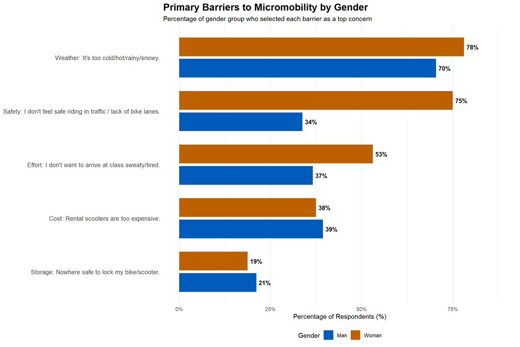

## Winter Walking Barriers

While walking is a carbon-free and efficient mode of travel for those living near campus, the harsh Buffalo winter introduces significant obstacles. The following visualization explores the specific factors that discourage students from walking to the North Campus during the winter months, even when snow may not be present on the ground.

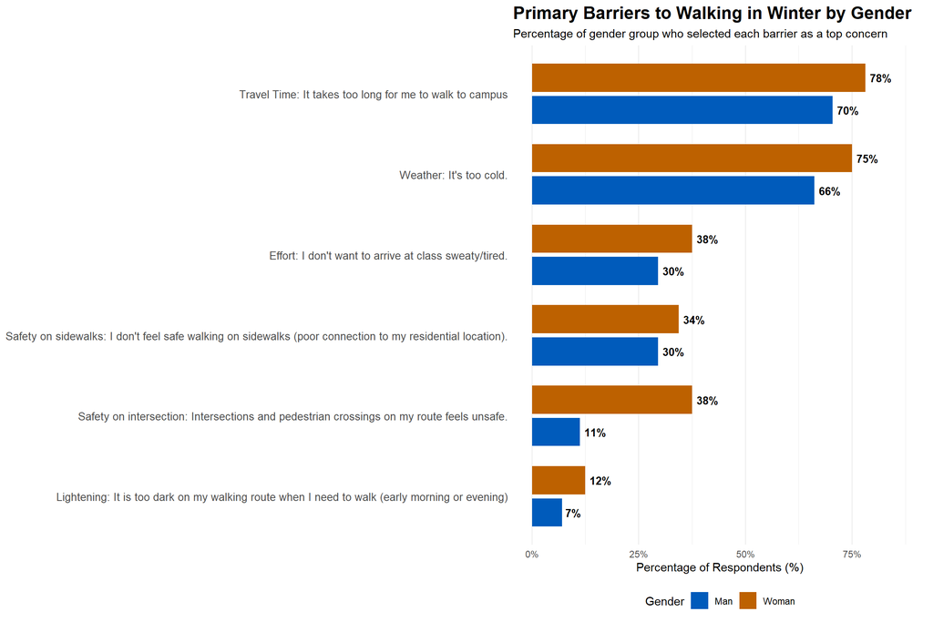

## Weather Resilience: Fair Weather Habits vs. Snow Day Likelihoods

Understanding how commuting behavior shifts during adverse weather is vital for campus accessibility planning. The following visualization explores the relationship between a student’s primary transportation mode during “fair weather” and their stated likelihood of using various modes during heavy snow.

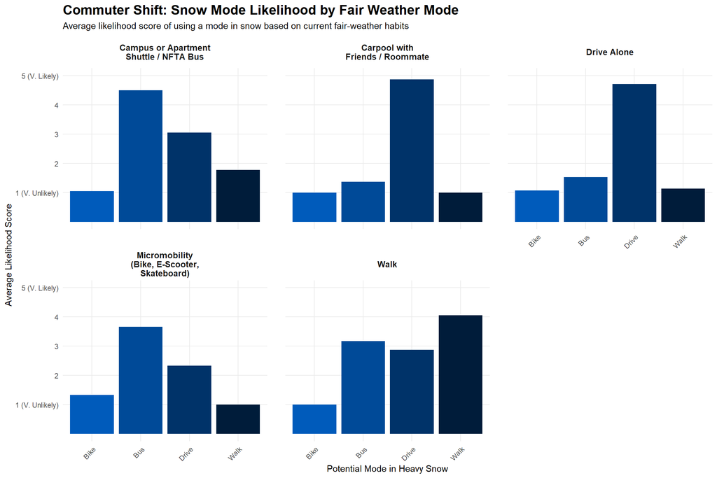

## Incentives to Reduce Single-Occupancy Vehicle Trips

To effectively reduce the number of single-occupancy vehicles on campus, it is crucial to identify which specific incentives or infrastructure improvements would successfully encourage students to leave their cars at home. The following visualization explores various “pull factors” and compares their perceived effectiveness between men and women.

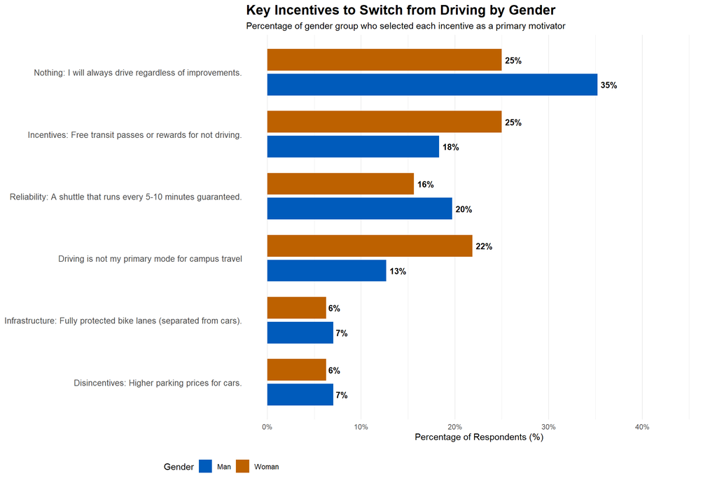